# Selective sweeps and genetic hitchhiking

Population Genetics Practical 14: Selection, linkage and diversity

## Learning objectives

Specify a two-locus selection and recombination model; trace a neutral allele carried by a beneficial background; compare recombination rates and initial backgrounds; and distinguish a mechanism from evidence for a sweep in genomic data.

Review haplotypes and LD, diversity and selection. Read alongside the slides on selective sweeps. All inputs are hypothetical and use base R.

## 1. Define the life cycle and initial haplotypes

Use an infinite deterministic population with haplotypes AB, Ab, aB and ab. A has reproductive weight $1+s$, while a has weight 1; B/b is neutral. First weight haplotypes by reproduction, then form random pairs and recombine at fraction r. The tracked population is a haplotype pool, not a diploid dominance model. There is no drift, mutation or migration.

Initially A has frequency 0.01 and occurs only on the B background. B has frequency 0.5. This represents selection starting from one marker background; we do not simulate the origin or establishment of a new beneficial mutation.

**Show R code**

```r
h0 <- c(AB=.01,Ab=0,aB=.49,ab=.5)
s <- .2
summary_h <- function(h) {
  stopifnot(identical(names(h),c("AB","Ab","aB","ab")),
            all(is.finite(h)),all(h>=-1e-12),abs(sum(h)-1)<1e-12)
  pA <- unname(h["AB"]+h["Ab"])
  pB <- unname(h["AB"]+h["aB"])
  c(pA=pA,pB=pB,D=unname(h["AB"])-pA*pB,HE_B=2*pB*(1-pB))
}
summary_h(h0)
```

```
   pA    pB     D  HE_B
0.010 0.500 0.005 0.500
```

## 2. Selection moves the linked neutral allele

Let $D=f_{AB}-p_Ap_B$. Weighting the A background gives

$$p_A^{(s)}=\frac{(1+s)p_A}{1+sp_A},\qquad
p_B^{(s)}-p_B=\frac{sD}{1+sp_A}.$$

The neutral allele changes because it is associated with the selected background. This is genetic hitchhiking, introduced by [Maynard Smith and Haigh (1974)](https://doi.org/10.1017/S0016672300014634).

After selection, calculate $D_s$ in the weighted pool. Recombination changes haplotypes by $rD_s(-1,+1,+1,-1)$, conserving both allele margins while reducing LD to $(1-r)D_s$.

**Show R code**

```r
sweep_step <- function(h,s,r) {
  summary_h(h)
  stopifnot(length(s)==1,is.finite(s),s>=0,
            length(r)==1,is.finite(r),r>=0,r<=.5)
  selected <- h*c(1+s,1+s,1,1)
  selected <- selected/sum(selected)
  Ds <- unname(summary_h(selected)["D"])
  next_h <- selected+r*Ds*c(-1,1,1,-1)
  summary_h(next_h)
  list(selected=selected,next_h=next_h)
}
step <- sweep_step(h0,s,.1)
before <- summary_h(h0)
after_selection <- summary_h(step$selected)
after <- summary_h(step$next_h)
stopifnot(abs(after_selection["pB"]-before["pB"]-
  s*before["D"]/(1+s*before["pA"]))<1e-12,
  max(abs(after[c("pA","pB")]-after_selection[c("pA","pB")]))<1e-12,
  abs(after["D"]-.9*after_selection["D"])<1e-12)
rbind(initial=before,selected=after_selection,recombined=after)
```

```
                   pA       pB           D     HE_B
initial    0.01000000 0.500000 0.005000000 0.500000
selected   0.01197605 0.500998 0.005976072 0.499998
recombined 0.01197605 0.500998 0.005378465 0.499998
```

## 3. Compare recombination rates

**Show R code**

```r
trajectory <- function(h,s,r,generations=100) {
  out <- matrix(NA_real_,generations+1,4,
                dimnames=list(NULL,names(summary_h(h))))
  out[1,] <- summary_h(h)
  for(t in seq_len(generations)) {
    h <- sweep_step(h,s,r)$next_h
    out[t+1,] <- summary_h(h)
  }
  out
}
rates <- c(0,.01,.1,.5)
paths <- lapply(rates,function(r) trajectory(h0,s,r))
# The selected-locus odds increase by factor 1+s each generation.
times <- 0:100
odds <- .01/.99*(1+s)^times
expected_A <- odds/(1+odds)
stopifnot(all(vapply(paths,function(x) max(abs(x[,"pA"]-expected_A))<1e-12,
                     logical(1))))
no_recomb_B <- expected_A+(1-expected_A)*(.49/.99)
stopifnot(max(abs(paths[[1]][,"pB"]-no_recomb_B))<1e-12)
```

**Show R code**

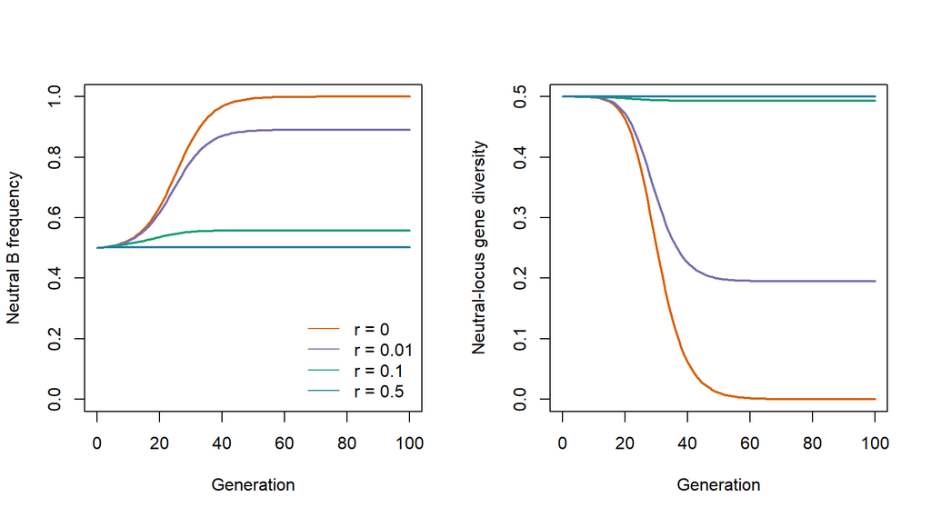

```r
local({
  old <- par(mfrow=c(1,2));on.exit(par(old))
  colors <- c("#d95f02","#7570b3","#1b9e77","#247BA0")
  matplot(times,sapply(paths,function(x) x[,"pB"]),type="l",lty=1,
          lwd=2,col=colors,ylim=c(0,1),xlab="Generation",ylab="Neutral B frequency")
  legend("bottomright",paste("r =",rates),col=colors,lty=1,bty="n")
  matplot(times,sapply(paths,function(x) x[,"HE_B"]),type="l",lty=1,
          lwd=2,col=colors,ylim=c(0,.5),xlab="Generation",ylab="Neutral-locus gene diversity")
})
```

The A trajectories coincide because recombination does not alter its marginal reproductive advantage here. The linked neutral locus has different trajectories. With no recombination, B approaches fixation as A becomes common; recombination allows A onto alternative marker backgrounds and preserves more marker diversity in these examples.

The deterministic allele approaches fixation without reaching it at a finite model step. The example does not include stochastic establishment or time to actual fixation. Recombination fraction is not physical distance; these curves are not a genomic scan or a measured width of a sweep.

## 4. Initial backgrounds matter

Start A at the same frequency but distribute it equally across B and b. Both loci initially have zero LD. There is no marker hitchhiking in this deterministic model even though A increases.

**Show R code**

```r
multiple_backgrounds <- c(AB=.005,Ab=.005,aB=.495,ab=.495)
multiple <- trajectory(multiple_backgrounds,s,0)
stopifnot(max(abs(multiple[,"pA"]-expected_A))<1e-12,
          max(abs(multiple[,"pB"]-.5))<1e-12,
          max(abs(multiple[,"D"]))<1e-12)
data.frame(initial_background=c("A only with B","A with both B and b"),
           terminal_A=c(paths[[1]][101,"pA"],multiple[101,"pA"]),
           terminal_B=c(paths[[1]][101,"pB"],multiple[101,"pB"]),
           terminal_HE=c(paths[[1]][101,"HE_B"],multiple[101,"HE_B"]))
```

```
   initial_background terminal_A terminal_B  terminal_HE
1       A only with B  0.9999988  0.9999994 1.207465e-06
2 A with both B and b  0.9999988  0.5000000 5.000000e-01
```

This comparison illustrates why selection need not erase variation on every marker background. Hard and soft sweep models distinguish beneficial origins and genealogical backgrounds. Our four-state model does not reconstruct those origins, so initial marker diversity alone does not classify a real sweep as hard or soft.

## 5. Interpret genomic signatures with alternatives

A recent sweep can motivate looking for reduced local diversity, unusually common haplotypes and LD patterns. A completed sweep need not retain high LD: fixed sites have no polymorphic LD correlation, and recombination continues to alter surrounding variation.

Low diversity alone cannot identify selection. Demography, mutation-rate variation, sampling, ascertainment and selection against linked deleterious alleles can also affect summaries. Establishing a genomic signal requires a suitable null model, genomic and recombination information, and a declared testing procedure. This practical demonstrates hitchhiking rather than qualifying a detection method.

## Exercises

1. Set s=0. Which allele margins remain unchanged even when recombination occurs?
2. Start A only on b, keeping its frequency 0.01 and B frequency 0.5. Predict the direction of B change.
3. Explain why the selected locus follows the same trajectory at all four recombination rates.
4. Would reduced diversity at a locus establish a selective sweep?

**Suggested solutions**

**Show R code**

```r
neutral <- trajectory(h0,0,.1)
stopifnot(max(abs(neutral[,"pA"]-.01))<1e-12,
          max(abs(neutral[,"pB"]-.5))<1e-12)
on_b <- c(AB=0,Ab=.01,aB=.5,ab=.49)
reverse_path <- trajectory(on_b,s,0)
stopifnot(reverse_path[101,"pB"]<.5)
summary_h(on_b)
```

```
    pA     pB      D   HE_B
 0.010  0.500 -0.005  0.500
```

Without selection, recombination preserves both margins while reducing LD. If A starts on b, D is negative and B declines through hitchhiking of its alternative. Recombination conserves the selected margin, and the fitness weight depends only on A. A low-diversity observation requires comparison with plausible alternative models.

## Package connections and next practical

These base R recursions illustrate population expectations relevant to `gpop`; no exported sweep API is assumed. Extending to finite chromosome inheritance requires an explicit supported simulation model in `gsim`. The existing selective-sweep Shiny source is an optional local tool with its own model; this practical does not change or validate it.

Continue to Practical 15: Coalescent history to view sampled variation through ancestry backwards in time.